# Import and explore covariates

## 3.2. Monthly proportional presence-absence

We will now create a proportional monthly variable for each species by determining how many months an animal was present, divided by the total months of data available.

```r
proportional_months <- presence_months %>%

  group_by(array, site, species) %>%

  summarize(months_active = n(),
            months_present = sum(presence),
            .groups = 'drop')
```

Let’s do a couple quick checks to make sure this worked. First, a visual inspection to make sure we have the same number of rows for each species and a reasonable range of active dates. Then, we’ll check if any of the presence values exceed the active values, which would indicate an error.

```r
summary(proportional_months)
```

```
##     array               site                 species     months_active
##  Length:5590        Length:5590        black bear: 430   Min.   : 1.00
##  Class :character   Class :character   caribou   : 430   1st Qu.:11.00
##  Mode  :character   Mode  :character   cougar    : 430   Median :12.00
##                                        coyote    : 430   Mean   :11.44
##                                        fisher    : 430   3rd Qu.:12.00
##                                        grey wolf : 430   Max.   :15.00
##                                        (Other)   :3010
##  months_present
##  Min.   : 0.000
##  1st Qu.: 0.000
##  Median : 0.000
##  Mean   : 1.754
##  3rd Qu.: 2.000
##  Max.   :15.000
##
```

```r
proportional_months %>%
  filter(months_present > months_active)
```

```
## # A tibble: 0 × 5
## # ℹ 5 variables: array <chr>, site <chr>, species <fct>, months_active <int>,
## #   months_present <dbl>
```

Now let’s pivot the data to wide format :) We will also rename the species since they’re now becoming column names and spaces or hyphens aren’t acceptable.

```r
proportional_months <- proportional_months %>%

  # pivot the data wider so there is a column for each species and 1 row per site
  pivot_wider(names_from = species,
              values_from = months_present) %>%

  # replace NAs with zeros in all species columns
  mutate(across(
    where(is.numeric),
    ~ replace_na(., 0))) %>%

  # ensure all species columns are numeric not integer
  mutate_if(is.integer,
            as.numeric) %>%

  # set the column names to lower case and replace the spaces with '_' (these are both personal preferences of mine)
  set_names(
    names(.) %>%
      tolower()%>%
      str_replace_all(pattern = ' ',
                      replacement = '_') %>%
      str_replace_all(pattern = '-',
                      replacement = "_"))
```

Now we can run the function below to create a second column for each species that will represent the number of absences (months the species was not detected) at each camera from the active months. This function was adopted from Marissa Dyck’s OSM 2022-2023 image processing script, found on the ACME GitHub.

```r
# replace all non-letter digits with underscores to match the column names in the response variable.
focal_species_colnames <- focal_species %>%
  str_replace_all(., pattern = ' ', replacement = '_') %>%
  str_replace_all(., pattern = '-', replacement = '_')

# first convert data to data frame not a tibble for function to work
proportional_months <- as.data.frame(proportional_months)

# create a vector of the species columns for the loop
# update our focal species list to match the new column names
for (species in focal_species_colnames) {

  if (is.numeric(proportional_months[,species]) & is.numeric(proportional_months$months_active)) {
    col_absence <- paste0("absent_", species)

    proportional_months[col_absence] <- proportional_months$months_active - proportional_months[,species]

  }
}

str(proportional_months)
```

```
## 'data.frame':    430 obs. of  29 variables:
##  $ array                   : chr  "LU1" "LU1" "LU1" "LU1" ...
##  $ site                    : chr  "LU1_10" "LU1_11" "LU1_13" "LU1_22" ...
##  $ months_active           : num  5 14 15 14 14 15 15 15 15 14 ...
##  $ black_bear              : num  3 4 7 8 9 4 5 7 7 8 ...
##  $ caribou                 : num  0 0 0 0 0 0 0 0 0 0 ...
##  $ cougar                  : num  0 1 0 1 0 0 0 0 0 0 ...
##  $ coyote                  : num  4 8 10 11 9 11 0 9 4 7 ...
##  $ fisher                  : num  3 3 3 2 1 1 1 0 3 3 ...
##  $ grey_wolf               : num  0 2 0 0 0 1 0 0 0 0 ...
##  $ lynx                    : num  0 1 0 1 1 0 0 0 2 1 ...
##  $ moose                   : num  2 5 9 1 0 2 4 1 0 3 ...
##  $ red_fox                 : num  0 2 0 0 0 0 0 4 0 0 ...
##  $ red_squirrel            : num  0 7 0 10 1 15 0 9 3 2 ...
##  $ snowshoe_hare           : num  1 3 0 8 2 2 0 12 4 7 ...
##  $ white_tailed_deer       : num  5 12 12 13 14 15 9 12 10 10 ...
##  $ wolverine               : num  0 0 0 0 0 0 0 0 0 0 ...
##  $ absent_black_bear       : num  2 10 8 6 5 11 10 8 8 6 ...
##  $ absent_caribou          : num  5 14 15 14 14 15 15 15 15 14 ...
##  $ absent_cougar           : num  5 13 15 13 14 15 15 15 15 14 ...
##  $ absent_coyote           : num  1 6 5 3 5 4 15 6 11 7 ...
##  $ absent_fisher           : num  2 11 12 12 13 14 14 15 12 11 ...
##  $ absent_grey_wolf        : num  5 12 15 14 14 14 15 15 15 14 ...
##  $ absent_lynx             : num  5 13 15 13 13 15 15 15 13 13 ...
##  $ absent_moose            : num  3 9 6 13 14 13 11 14 15 11 ...
##  $ absent_red_fox          : num  5 12 15 14 14 15 15 11 15 14 ...
##  $ absent_white_tailed_deer: num  0 2 3 1 0 0 6 3 5 4 ...
##  $ absent_wolverine        : num  5 14 15 14 14 15 15 15 15 14 ...
##  $ absent_snowshoe_hare    : num  4 11 15 6 12 13 15 3 11 7 ...
##  $ absent_red_squirrel     : num  5 7 15 4 13 0 15 6 12 12 ...
```

Let’s adjust the black bear data to accommodate hibernation. We want bear data to represent only April to November.

```r
operating_months_bears <- operating_months %>%

  filter(month %in% c("4", "5", "6", "7", "8", "9", "10", "11")) %>%

  group_by(array, site) %>%

  summarize(months_active_bears = n(),
            .groups = 'drop')

# Update the months_active field for bears
proportional_months <- proportional_months %>%

  left_join(operating_months_bears, by = c('array', 'site')) %>%

  # overwrite absent black bear column
  mutate(absent_black_bear = months_active_bears - black_bear) %>%

  # get rid of unnecessary columns for active months
  select(-months_active_bears)
```

Save the file:

```r
write_csv(proportional_months, "./data/processed/OSM_proportional_monthly_presence_2021_2022_2023.csv")
```

Clean up our workspace:

```r
rm(operating_months_bears, operating_months, indet_months)
```

## 3.3. Weekly independent detections and presence-absence

Bin the operating data weekly and retain weeks with >4 days of data. There is a handy function to do this!! `floor_date()` takes a date-time object and rounds it down to the nearest boundary of the specified time unit, starting on Sunday (default case). In this step, we will round down our operating data to the nearest week so we can bin it. We’ll re-extract the month and year fields later.

```r
operating_weeks <- operating %>%

  mutate(week = floor_date(date, unit = "week")) %>%

  group_by(array, site, week) %>%

  summarize(n_days = n()) %>%

  filter(n_days >= 4) # retain weeks where there are 15 days of data only.
```

Then, let’s bin the independent detections data into weeks. This data frame will only contain the positive detections. i.e., if a species was undetected for a given site/week, there will be no row.

```r
indet_weeks <- indet %>%

  filter(species %in% focal_species) %>%

  mutate(week = floor_date(event_start, unit = "week")) %>%

  group_by(array, site, week, species) %>%

  summarize(presence = 1,
            detections = n(),
            .groups = 'drop')
```

Then, let’s merge this to the operating data using left_join. This will ensure that our ‘absence’ cases now show up in the dataset.

```r
presence_weeks <- operating_weeks %>%

  # Ensure that we have a new row for each species x week combination.
  crossing(species = focal_species) %>%

  left_join(indet_weeks, by = c("array", "site", "species", "week")) %>%

  # Fill missing presence and detections with 0
  mutate(presence = replace_na(presence, 0),
         detections = replace_na(detections, 0),
         species = as.factor(species)) %>%

  mutate(month = month(week),
         year = year(week)) %>%

  select(-n_days)

summary(presence_weeks)
```

```
##     array               site                week
##  Length:277017      Length:277017      Min.   :2021-07-11 00:00:00.00
##  Class :character   Class :character   1st Qu.:2022-11-20 00:00:00.00
##  Mode  :character   Mode  :character   Median :2023-08-06 00:00:00.00
##                                        Mean   :2023-06-17 05:29:46.56
##                                        3rd Qu.:2024-03-03 00:00:00.00
##                                        Max.   :2024-09-22 00:00:00.00
##
##        species          presence         detections          month
##  black bear: 21309   Min.   :0.00000   Min.   : 0.0000   Min.   : 1.000
##  caribou   : 21309   1st Qu.:0.00000   1st Qu.: 0.0000   1st Qu.: 4.000
##  cougar    : 21309   Median :0.00000   Median : 0.0000   Median : 7.000
##  coyote    : 21309   Mean   :0.06325   Mean   : 0.1084   Mean   : 6.642
##  fisher    : 21309   3rd Qu.:0.00000   3rd Qu.: 0.0000   3rd Qu.:10.000
##  grey wolf : 21309   Max.   :1.00000   Max.   :24.0000   Max.   :12.000
##  (Other)   :149163
##       year
##  Min.   :2021
##  1st Qu.:2022
##  Median :2023
##  Mean   :2023
##  3rd Qu.:2024
##  Max.   :2024
##
```

Save the file:

```r
write_csv(presence_weeks, "./data/processed/OSM_weekly_detections_2021_2022_2023.csv")
```

## 3.4. Weekly proportional presence-absence

We will now create a proportional weekly variable for each species by determining how many weeks an animal was present, divided by the total weeks of data available.

```r
proportional_weeks <- presence_weeks %>%

  group_by(array, site, species) %>%

  summarize(weeks_active = n(),
            weeks_present = sum(presence),
            .groups = 'drop')
```

Let’s do a couple quick checks to make sure this worked. First, a visual inspection to make sure we have the same number of rows for each species and a reasonable range of active dates. Then, we’ll check if any of the presence values exceed the active values, which would indicate an error.

```r
summary(proportional_weeks)
```

```
##     array               site                 species      weeks_active
##  Length:5590        Length:5590        black bear: 430   Min.   : 4.00
##  Class :character   Class :character   caribou   : 430   1st Qu.:49.00
##  Mode  :character   Mode  :character   cougar    : 430   Median :51.00
##                                        coyote    : 430   Mean   :49.56
##                                        fisher    : 430   3rd Qu.:53.00
##                                        grey wolf : 430   Max.   :65.00
##                                        (Other)   :3010
##  weeks_present
##  Min.   : 0.000
##  1st Qu.: 0.000
##  Median : 0.000
##  Mean   : 3.135
##  3rd Qu.: 3.000
##  Max.   :58.000
##
```

```r
proportional_weeks %>%
  filter(weeks_present > weeks_active)
```

```
## # A tibble: 0 × 5
## # ℹ 5 variables: array <chr>, site <chr>, species <fct>, weeks_active <int>,
## #   weeks_present <dbl>
```

Now let’s pivot the data to wide format :)

```r
proportional_weeks <- proportional_weeks %>%

  # pivot the data wider so there is a column for each species and 1 row per site
  pivot_wider(names_from = species,
              values_from = weeks_present) %>%

  # replace NAs with zeros in all species columns
  mutate(across(
    where(is.numeric),
    ~ replace_na(., 0))) %>%

  # ensure all species columns are numeric not integer
  mutate_if(is.integer,
            as.numeric) %>%

  # set the column names to lower case and replace the spaces with '_' (these are both personal preferences of mine)
  set_names(
    names(.) %>%
      tolower()%>%
      str_replace_all(pattern = ' ',
                      replacement = '_') %>%
      str_replace_all(pattern = '-',
                      replacement = "_"))
```

Now we can run the function below to create a second column for each species that will represent the number of absences (weeks the species was not detected) at each camera from the active weeks. This function was adopted from Marissa Dyck’s OSM 2022-2023 image processing script, found on the ACME GitHub.

```r
# first convert data to data frame not a tibble for function to work
proportional_weeks <- as.data.frame(proportional_weeks)

# create a vector of the species columns for the loop
# update our focal species list to match the new column names
for (species in focal_species_colnames) {

  if (is.numeric(proportional_weeks[,species]) & is.numeric(proportional_weeks$weeks_active)) {
    col_absence <- paste0("absent_", species)

    proportional_weeks[col_absence] <- proportional_weeks$weeks_active - proportional_weeks[,species]

  }
}

str(proportional_weeks)
```

```
## 'data.frame':    430 obs. of  29 variables:
##  $ array                   : chr  "LU1" "LU1" "LU1" "LU1" ...
##  $ site                    : chr  "LU1_10" "LU1_11" "LU1_13" "LU1_22" ...
##  $ weeks_active            : num  24 64 65 64 64 65 65 64 64 62 ...
##  $ black_bear              : num  4 7 12 11 20 4 9 19 12 10 ...
##  $ caribou                 : num  0 0 0 0 0 0 0 0 0 0 ...
##  $ cougar                  : num  0 1 0 1 0 0 0 0 0 0 ...
##  $ coyote                  : num  4 11 12 18 13 22 0 14 5 13 ...
##  $ fisher                  : num  6 4 3 4 1 1 1 0 3 4 ...
##  $ grey_wolf               : num  0 2 0 0 0 1 0 0 0 0 ...
##  $ lynx                    : num  0 1 0 1 1 0 0 0 2 1 ...
##  $ moose                   : num  2 7 14 1 0 2 6 2 0 3 ...
##  $ red_fox                 : num  0 2 0 0 0 0 0 7 0 0 ...
##  $ red_squirrel            : num  0 9 0 26 1 47 0 19 5 3 ...
##  $ snowshoe_hare           : num  1 6 0 13 2 3 0 31 8 13 ...
##  $ white_tailed_deer       : num  22 34 41 28 43 40 17 20 13 20 ...
##  $ wolverine               : num  0 0 0 0 0 0 0 0 0 0 ...
##  $ absent_black_bear       : num  20 57 53 53 44 61 56 45 52 52 ...
##  $ absent_caribou          : num  24 64 65 64 64 65 65 64 64 62 ...
##  $ absent_cougar           : num  24 63 65 63 64 65 65 64 64 62 ...
##  $ absent_coyote           : num  20 53 53 46 51 43 65 50 59 49 ...
##  $ absent_fisher           : num  18 60 62 60 63 64 64 64 61 58 ...
##  $ absent_grey_wolf        : num  24 62 65 64 64 64 65 64 64 62 ...
##  $ absent_lynx             : num  24 63 65 63 63 65 65 64 62 61 ...
##  $ absent_moose            : num  22 57 51 63 64 63 59 62 64 59 ...
##  $ absent_red_fox          : num  24 62 65 64 64 65 65 57 64 62 ...
##  $ absent_white_tailed_deer: num  2 30 24 36 21 25 48 44 51 42 ...
##  $ absent_wolverine        : num  24 64 65 64 64 65 65 64 64 62 ...
##  $ absent_snowshoe_hare    : num  23 58 65 51 62 62 65 33 56 49 ...
##  $ absent_red_squirrel     : num  24 55 65 38 63 18 65 45 59 59 ...
```

Let’s adjust the black bear data to accommodate hibernation. We want bear data to represent only April to November.

```r
operating_weeks_bears <- operating_weeks %>%

  mutate(month = month(week)) %>%

  filter(month %in% c(4:11)) %>%

  group_by(array, site) %>%

  summarize(weeks_active_bears = n(),
            .groups = 'drop')

# Update the weeks_active field for bears
proportional_weeks <- proportional_weeks %>%

  left_join(operating_weeks_bears, by = c('array', 'site')) %>%

  # overwrite absent black bear column
  mutate(absent_black_bear = weeks_active_bears - black_bear) %>%

  # get rid of unnecessary columns for active weeks
  select(-weeks_active_bears)
```

Save the file:

```r
write_csv(proportional_weeks, "./data/processed/OSM_proportional_weekly_presence_2021_2022_2023.csv")
```

Clean up our workspace:

```r
rm(operating_weeks_bears, operating_weeks, indet_weeks)
```

# 4. Visualize the response variables

Let’s make a couple quick figures to represent our detections and get a sense for the amount of variation between sites and between arrays.

## 4.1. Monthly detections per site/array

This is a good proxy for overall density of a species across each landscape.

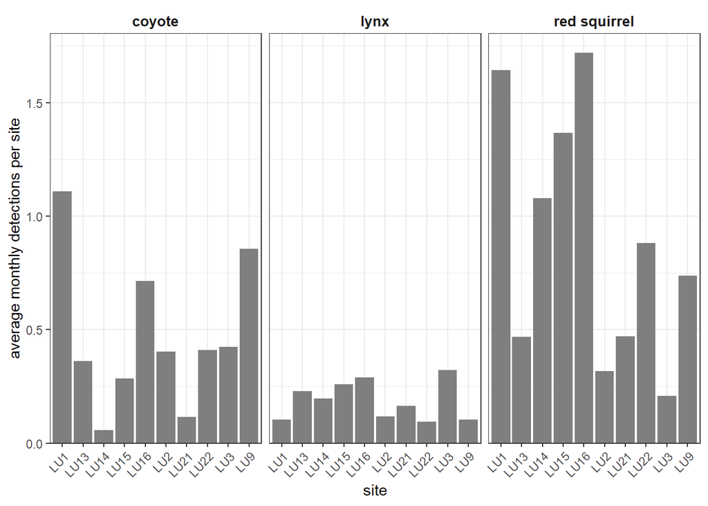

```r
fig_month_det <- presence_months %>%

  filter(species %in% c('lynx', 'coyote', 'red squirrel')) %>%

  group_by(array, species) %>%

  summarize(total_det = sum(detections),
            total_months = n(),
            average_det = total_det / total_months) %>%

  ggplot(., aes(x = array, y = average_det)) +

    geom_bar(stat = "identity", position = "dodge", fill = 'grey50') +

    facet_wrap(~species, scales = 'fixed') +

    labs(x = "site",
         y = "average monthly detections per site") +

    theme_bw() +

    theme(
         axis.text.x = element_text(angle = 45, hjust = 1),  # Rotate x-axis labels
         strip.background = element_blank(),  # Remove facet background
         strip.text = element_text(face = "bold", size = 10)
         ) +

    scale_y_continuous(expand = expansion(mult = c(0, 0.05)))  # Remove bottom space, keep small top space
fig_month_det
```

## 4.2. Weekly detections per site/array

This is a good proxy for overall density of a species across each landscape. Let’s see if it varies much from our monthly metric.

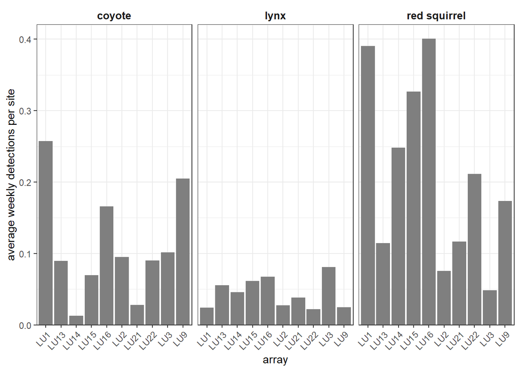

```r
fig_week_det <- presence_weeks %>%

  filter(species %in% c('lynx', 'coyote', 'red squirrel')) %>%

  group_by(array, species) %>%

  summarize(total_det = sum(detections),
            total_weeks = n(),
            average_det = total_det / total_weeks) %>%

  ggplot(., aes(x = array, y = average_det)) +

    geom_bar(stat = "identity", position = "dodge", fill = 'grey50') +

    facet_wrap(~species, scales = 'fixed') +

    labs(x = "array",
         y = "average weekly detections per site") +

    theme_bw() +

    theme(
         axis.text.x = element_text(angle = 45, hjust = 1),  # Rotate x-axis labels
         strip.background = element_blank(),  # Remove facet background
         strip.text = element_text(face = "bold", size = 10)
         ) +

    scale_y_continuous(expand = expansion(mult = c(0, 0.05)))  # Remove bottom space, keep small top space
fig_week_det
```

## 4.2. Naive occupancy per array

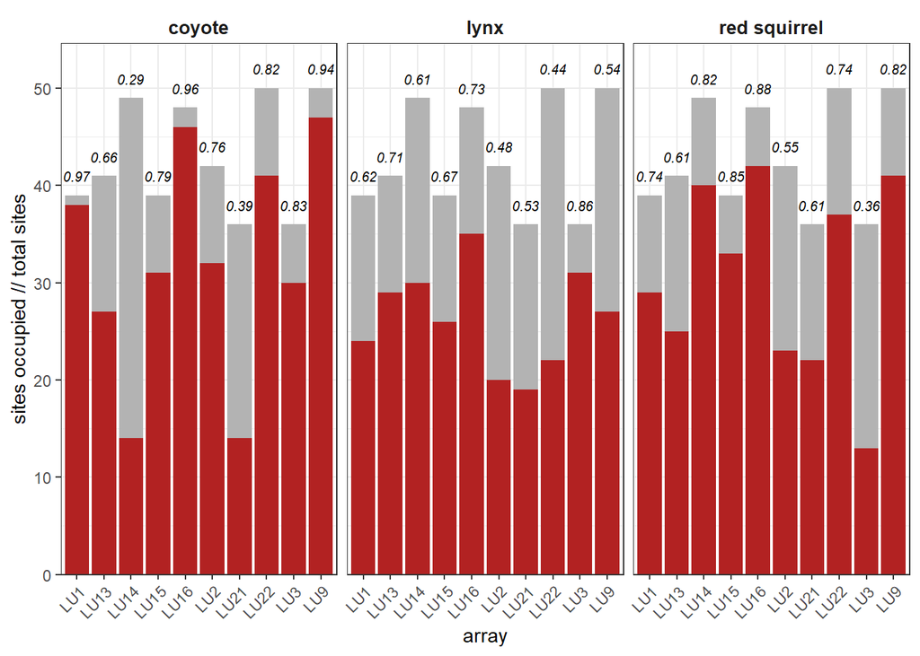

```r
fig_occ_total <- presence_months %>%

  filter(species %in% c('lynx', 'coyote', 'red squirrel')) %>%

#  filter(species %in% c('red squirrel')) %>%

  group_by(array, site, species) %>%

  summarize(presence = max(presence)) %>%

  group_by(array, species) %>%

  summarize(n_sites = n(),
            n_present = sum(presence),
            naive_occ = n_present / n_sites,
            .groups = 'drop') %>%

  ggplot(., aes(x = array)) +

    geom_bar(aes(y = n_sites), stat = "identity", fill = "grey70") +  # Total sites in grey

    geom_bar(aes(y = n_present), stat = "identity", fill = "firebrick") +  # Present sites in red

    geom_text(aes(y = n_sites + 2, label = round(naive_occ, 2)), size = 2.7, fontface = "italic") +  # Label above bars

    theme_bw() +

    facet_wrap(~species, scales = 'fixed') +

    labs(x = "array",
         y = "sites occupied // total sites") +


    theme(
         axis.text.x = element_text(angle = 45, hjust = 1),  # Rotate x-axis labels
         strip.background = element_blank(),  # Remove facet background
         strip.text = element_text(face = "bold", size = 10)
         ) +

    scale_y_continuous(expand = expansion(mult = c(0, 0.05)))  # Remove bottom space, keep small top space
fig_occ_total
```

## 4.3. Temporal variation in detections

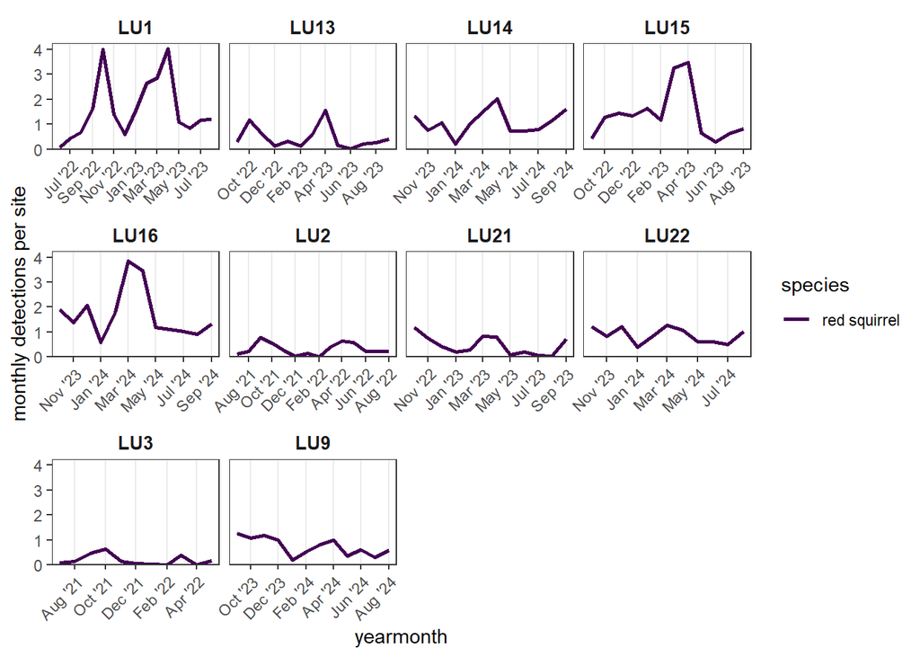

```r
fig_seasonal_det <- presence_months %>%

  filter(species %in% c('red squirrel')) %>%

  group_by(array, site, species, year, month) %>%

  summarize(det = sum(detections)) %>%

  group_by(array, species, year, month) %>%

  summarize(n_sites = n(),
            total_det = sum(det),
            avg_det = total_det / n_sites) %>%

  mutate(yearmonth = ym(paste(year, month, sep = "-"))) %>%  # Creates Year-Month column

  ggplot(., aes(x = yearmonth, y = avg_det, color = species)) +

    #geom_bar(stat = "identity", position = "dodge", fill = 'grey20') +

    geom_line(linewidth = 1) +  # Use lines instead of bars

    scale_color_viridis_d() +

    #geom_point(size = 1.5, color = 'grey20') +  # Optional: Add points to mark data

    facet_wrap(~array, scales = 'free_x') +

    labs(y = "monthly detections per site") +

    theme_bw() +

    theme(
         axis.text.x = element_text(angle = 45, hjust = 1),  # Rotate x-axis labels
         strip.background = element_blank(),  # Remove facet background
         strip.text = element_text(face = "bold", size = 10),
         panel.background = element_rect(fill = "white"),  # Set light gray background
         panel.grid.major.y = element_blank(),
         panel.grid.minor.y = element_blank()# Remove horizontal grid lines on the plot
         ) +

    scale_x_date(date_labels = "%b '%y", date_breaks = "2 months", minor_breaks = NULL) +  # 6-month interval

    scale_y_continuous(expand = expansion(mult = c(0, 0.05)))  # Remove bottom space, keep small top space
fig_seasonal_det
```

It doesn’t look too too variable to be quite honest, I think that we are likely not introducing any crazy bias into our data by using a proportional response with variable months among arrays/sites. The coolest thing to see is the huge difference in detections per site.

# 5. Summary statistics

## 5.1. Cameras and camera-trap survey effort

```r
n_camera_days <- operating %>%

  group_by(array, site) %>%

  summarize(camera_days = n()) %>%

  # Any cams with <4 days of data were inevitably filtered out.
  # For now we have no filters applied based on the number of weeks.
  filter(camera_days >= 4)
sum(n_camera_days$camera_days)
```

```
## [1] 149273
```

```r
sd(n_camera_days$camera_days)
```

```
## [1] 67.16344
```

```r
mean(n_camera_days$camera_days)
```

```
## [1] 347.1465
```

```r
min(n_camera_days$camera_days)
```

```
## [1] 32
```

```r
max(n_camera_days$camera_days)
```

```
## [1] 455
```

```r
n_cameras <- n_camera_days %>%

  group_by(array) %>%

  summarize(cams = n())

sum(n_cameras$cams)
```

```
## [1] 430
```

```r
min(n_cameras$cams)
```

```
## [1] 36
```

```r
max(n_cameras$cams)
```

```
## [1] 50
```

```r
mean(n_cameras$cams)
```

```
## [1] 43
```

## 5.2. Number of images and independent detections

```r
osm_image <- list.files(path="./data/raw/",
                               pattern="OSM_timelapse",
                               full.names = TRUE) %>%
      map_dfr(.,
          ~read_csv(.x,
                   col_types = cols(datetime = col_character(), # we will fix this later
                                    site = col_character(),
                                    total = col_integer(),
                                    group_count = col_integer(),
                                    comments = col_character(),
                                    species = col_factor(),
                                    otherspecify = col_character(),
                                    snow = col_factor(),
                                    empty = col_logical())
          ) %>%

            set_names(tolower(names(.))) %>%

            select(-array, -camera) %>%

            # Remove "Z" and "T" to brute force the timestamps
            mutate(datetime = datetime %>% str_replace_all("Z", "") %>% str_replace_all("T", " "),
                   datetime = as_datetime(datetime),
                   datasource = paste0(.x),
                   year = year(datetime),
                   month = month(datetime),
                   day = day(datetime)) %>%

            mutate(
              site = gsub("-", "_", site) %>% # First, replace the hyphen with underscore
                gsub("_0+", "_", .) %>% # Then, remove leading zeros after the underscore
                gsub(" ", "", .) %>% # Then, remove any spaces
                gsub("LU0", "LU", .) %>% # Remove leading zeros from LU names for consistency
                as.factor(.), # Then, convert back to factor
               ) %>%

            # Create some extra columns
            separate_wider_delim(site,
                                 delim = '_',
                                 names = c('array', 'camera'),
                                 cols_remove = FALSE) %>%

            # specify format of new columns
            mutate(
              array = as.factor(array),
              camera = as.factor(camera)
              ) %>%

            select(file, relativepath, array, camera, site, snow, datetime,
                   year, month, day, classifier, species, total, group_count, comments,
                   empty, datasource, cameramalfunction)
          )
osm_image %>%

  filter(species == "Red squirrel",
         empty == FALSE) %>%
  nrow(.)
```

```
## [1] 7399
```

```r
n_indet <- indet %>%

  group_by(species) %>%

  summarize(detections = n())
```